# ReneWind

## Test set final performance

```python
tsdata = pd.read_csv("Test.csv")
```

```python
tsdata.shape
```

```
(10000, 41)
```

```python
tsdata.head()
```

|  | V1 | V2 | V3 | V4 | V5 | V6 | V7 | V8 | V9 | V10 | V11 | V12 | V13 | V14 | V15 | V16 | V17 | V18 | V19 | V20 | V21 | V22 | V23 | V24 | V25 | V26 | V27 | V28 | V29 | … |
| --- | --- | --- | --- | --- | --- | --- | --- | --- | --- | --- | --- | --- | --- | --- | --- | --- | --- | --- | --- | --- | --- | --- | --- | --- | --- | --- | --- | --- | --- | --- |
| 0 | -0.613 | -3.820 | 2.202 | 1.300 | -1.185 | -4.496 | -1.836 | 4.723 | 1.206 | -0.342 | -5.123 | 1.017 | 4.819 | 3.269 | -2.984 | 1.387 | 2.032 | -0.512 | -1.023 | 7.339 | -2.242 | 0.155 | 2.054 | -2.772 | 1.851 | -1.789 | -0.277 | -1.255 | -3.833 | … |
| 1 | -0.733 | 2.210 | 8.083 | 7.063 | -1.510 | -3.261 | -3.334 | -3.019 | 3.557 | -1.511 | -6.695 | -1.937 | 0.141 | -3.471 | -4.233 | -10.416 | 5.479 | -0.023 | 6.036 | 6.603 | -8.320 | 0.104 | -6.879 | 1.457 | 2.110 | 3.381 | -4.467 | 0.996 | -1.409 | … |
| 2 | 0.390 | -0.512 | 0.527 | -2.577 | -1.017 | 2.235 | -0.441 | -4.406 | -0.333 | 1.967 | 1.797 | 0.410 | 0.638 | -1.390 | -1.883 | -5.018 | -3.827 | 2.418 | 1.762 | -3.242 | -3.193 | 1.857 | -1.708 | 0.633 | -0.588 | 0.084 | 3.014 | -0.182 | 0.224 | … |
| 3 | 3.412 | 1.153 | 2.114 | -2.275 | 0.088 | -0.010 | 0.514 | -1.371 | 1.863 | -0.031 | -0.414 | -1.567 | 3.184 | 0.864 | -0.417 | -0.996 | -3.087 | -0.648 | -2.732 | -2.056 | -1.620 | -0.091 | -1.512 | -3.892 | 1.646 | 3.147 | 4.442 | -2.524 | -2.434 | … |
| 4 | -0.875 | -0.641 | 4.084 | -1.590 | 0.526 | -1.958 | -0.695 | 1.347 | -1.732 | 0.466 | -4.928 | 3.565 | -0.449 | -0.656 | -0.167 | -1.630 | 2.292 | 2.396 | 0.601 | 1.794 | -2.120 | 0.482 | -0.841 | 1.790 | 1.874 | 0.364 | -0.169 | -0.484 | -2.119 | … |

```python
tsdata.describe().T
```

|  | count | mean | std | min | 25% | 50% | 75% | max |
| --- | --- | --- | --- | --- | --- | --- | --- | --- |
| V1 | 9989.000 | -0.260 | 3.440 | -12.382 | -2.700 | -0.719 | 1.861 | 13.504 |
| V2 | 9993.000 | 0.417 | 3.160 | -11.625 | -1.701 | 0.456 | 2.526 | 14.079 |
| V3 | 10000.000 | 2.555 | 3.395 | -12.941 | 0.238 | 2.283 | 4.656 | 15.409 |
| V4 | 10000.000 | -0.054 | 3.462 | -14.682 | -2.371 | -0.169 | 2.144 | 12.896 |
| V5 | 10000.000 | -0.085 | 2.102 | -7.712 | -1.593 | -0.144 | 1.324 | 7.673 |
| V6 | 10000.000 | -1.014 | 2.039 | -8.949 | -2.377 | -1.015 | 0.354 | 6.273 |
| V7 | 10000.000 | -0.908 | 1.737 | -8.124 | -2.035 | -0.938 | 0.189 | 7.616 |
| V8 | 10000.000 | -0.599 | 3.343 | -12.710 | -2.684 | -0.387 | 1.698 | 10.792 |
| V9 | 10000.000 | 0.026 | 2.180 | -7.570 | -1.490 | -0.086 | 1.466 | 8.851 |
| V10 | 10000.000 | 0.019 | 2.169 | -8.291 | -1.362 | 0.150 | 1.537 | 7.691 |
| V11 | 10000.000 | -1.944 | 3.105 | -15.384 | -3.988 | -1.970 | 0.067 | 10.226 |
| V12 | 10000.000 | 1.551 | 2.906 | -10.650 | -0.465 | 1.455 | 3.516 | 12.984 |
| V13 | 10000.000 | 1.618 | 2.863 | -13.832 | -0.126 | 1.721 | 3.468 | 12.620 |
| V14 | 10000.000 | -0.941 | 1.816 | -7.814 | -2.160 | -0.948 | 0.262 | 6.180 |
| V15 | 10000.000 | -2.452 | 3.324 | -15.527 | -4.429 | -2.408 | -0.446 | 11.673 |
| V16 | 10000.000 | -3.016 | 4.276 | -20.986 | -5.682 | -2.794 | -0.120 | 13.976 |
| V17 | 10000.000 | -0.154 | 3.363 | -13.418 | -2.287 | -0.010 | 2.041 | 19.777 |
| V18 | 10000.000 | 1.180 | 2.566 | -12.214 | -0.401 | 0.877 | 2.556 | 13.642 |
| V19 | 10000.000 | 1.218 | 3.415 | -14.170 | -1.055 | 1.326 | 3.576 | 13.038 |
| V20 | 10000.000 | 0.078 | 3.704 | -13.720 | -2.417 | 0.079 | 2.529 | 14.497 |
| V21 | 10000.000 | -3.676 | 3.579 | -17.201 | -6.022 | -3.654 | -1.307 | 16.218 |
| V22 | 10000.000 | 0.950 | 1.622 | -8.832 | -0.083 | 0.976 | 2.005 | 7.505 |
| V23 | 10000.000 | -0.450 | 4.063 | -15.818 | -3.167 | -0.259 | 2.392 | 13.511 |
| V24 | 10000.000 | 1.093 | 3.915 | -12.749 | -1.577 | 0.918 | 3.537 | 17.806 |
| V25 | 10000.000 | 0.035 | 2.021 | -6.770 | -1.339 | 0.061 | 1.426 | 6.557 |
| V26 | 10000.000 | 1.878 | 3.422 | -11.414 | -0.265 | 1.973 | 4.170 | 17.528 |
| V27 | 10000.000 | -0.558 | 4.402 | -14.219 | -3.634 | -0.869 | 2.253 | 17.290 |
| V28 | 10000.000 | -0.885 | 1.928 | -7.933 | -2.169 | -0.934 | 0.396 | 7.416 |
| V29 | 10000.000 | -1.040 | 2.660 | -10.655 | -2.815 | -1.264 | 0.554 | 14.039 |
| V30 | 10000.000 | -0.067 | 3.039 | -14.054 | -1.950 | 0.138 | 2.002 | 10.315 |
| V31 | 10000.000 | 0.483 | 3.451 | -13.878 | -1.770 | 0.513 | 2.773 | 13.190 |
| V32 | 10000.000 | 0.253 | 5.503 | -20.520 | -3.459 | -0.013 | 3.762 | 26.539 |
| V33 | 10000.000 | 0.008 | 3.552 | -14.904 | -2.280 | -0.099 | 2.198 | 13.324 |
| V34 | 10000.000 | -0.423 | 3.168 | -17.135 | -2.066 | -0.203 | 1.472 | 14.581 |
| V35 | 10000.000 | 2.258 | 2.919 | -19.522 | 0.375 | 2.149 | 4.088 | 13.489 |
| V36 | 10000.000 | 1.550 | 3.794 | -14.912 | -0.892 | 1.620 | 4.061 | 17.116 |
| V37 | 10000.000 | -0.006 | 1.782 | -5.362 | -1.278 | -0.150 | 1.193 | 7.682 |
| V38 | 10000.000 | -0.373 | 3.998 | -15.335 | -3.004 | -0.362 | 2.335 | 13.726 |
| V39 | 10000.000 | 0.920 | 1.726 | -7.147 | -0.225 | 0.933 | 2.097 | 7.234 |
| V40 | 10000.000 | -0.937 | 3.011 | -10.779 | -2.993 | -0.986 | 1.085 | 10.392 |
| Target | 10000.000 | 0.055 | 0.227 | 0.000 | 0.000 | 0.000 | 0.000 | 1.000 |

```python
tsdata.info()
```

```
<class 'pandas.core.frame.DataFrame'>
RangeIndex: 10000 entries, 0 to 9999
Data columns (total 41 columns):
 #   Column  Non-Null Count  Dtype
---  ------  --------------  -----
 0   V1      9989 non-null   float64
 1   V2      9993 non-null   float64
 2   V3      10000 non-null  float64
 3   V4      10000 non-null  float64
 4   V5      10000 non-null  float64
 5   V6      10000 non-null  float64
 6   V7      10000 non-null  float64
 7   V8      10000 non-null  float64
 8   V9      10000 non-null  float64
 9   V10     10000 non-null  float64
```

[output cut: 33 more lines]

```python
tsdata.duplicated().sum()
```

```
0
```

```python
tsdata.isnull().sum()
```

```
V1        11
V2         7
V3         0
V4         0
V5         0
V6         0
V7         0
V8         0
V9         0
V10        0
V11        0
V12        0
V13        0
V14        0
V15        0
V16        0
V17        0
V18        0
V19        0
V20        0
V21        0
V22        0
V23        0
V24        0
V25        0
V26        0
V27        0
V28        0
V29        0
V30        0
V31        0
V32        0
V33        0
V34        0
V35        0
V36        0
V37        0
V38        0
V39        0
V40        0
Target     0
dtype: int64
```

```python
# Separating target variable and other variables
X_test = tsdata.drop(columns="Target")
y_test = tsdata["Target"]
```

### Missing Value Treatment

```python
X_test = imputer.transform(X_test)
```

### Performance on the test set

```python
# CV Score
print("\n" "Cross-Validation Performance:" "\n")

model = RandomForestClassifier(random_state=1)
scoring = scorer
kfold = StratifiedKFold(
    n_splits=5, shuffle=True, random_state=1
)  # Setting number of splits equal to 5
cv_result = cross_val_score(
    estimator=model, X=X_test, y=y_test, scoring=scoring, cv=kfold
)
print("{}: {}".format("Random Forest", cv_result.mean() * 100))
```

```
Cross-Validation Performance:

Random Forest: 64.6643507016016
```

```python
# Calculating different metrics on the test set
Random_random_test = model_performance_classification_sklearn(
    Random_tuned, X_test, y_test
)
print("Test performance:")
Random_random_test
```

```
Test performance:
```

|  | Accuracy | Recall | Precision | F1 | Minimum_Vs_Model_cost |
| --- | --- | --- | --- | --- | --- |
| 0 | 0.990 | 0.861 | 0.944 | 0.901 | 0.801 |

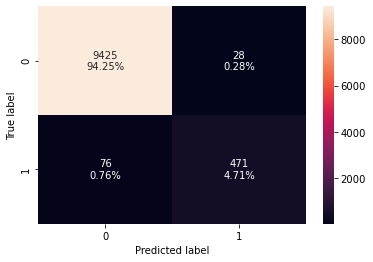

```python
# creating confusion matrix
confusion_matrix_sklearn(Random_tuned, X_test, y_test)
```

**Observations**

- The model provides overall good Metrics scores on Test data
- The model is giving a CV score of 64 on Test Data.

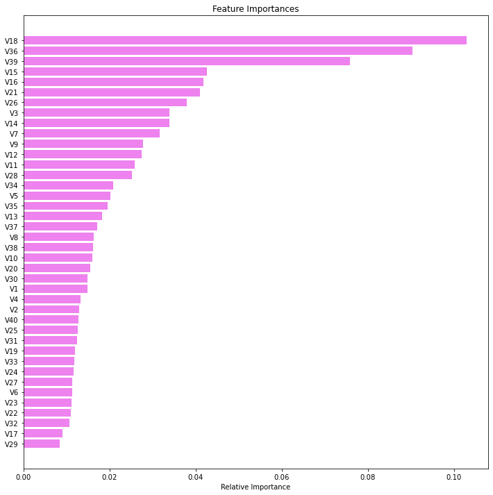

```python
feature_names = X.columns
importances = Random_tuned.feature_importances_
indices = np.argsort(importances)

plt.figure(figsize=(12, 12))
plt.title("Feature Importances")
plt.barh(range(len(indices)), importances[indices], color="violet", align="center")
plt.yticks(range(len(indices)), [feature_names[i] for i in indices])
plt.xlabel("Relative Importance")
plt.show()
```

- The important Predictors affecting the Target variable are V18, V36 and V39.

## Pipelines to build the final model

```python
from sklearn.svm import SVC
```

```python
from sklearn.pipeline import Pipeline

pipe = Pipeline([(" scaler", MinMaxScaler()), (" svm", SVC())])
```

```python
pipe.fit(X_train, y_train)
```

```
Pipeline(steps=[(' scaler', MinMaxScaler()), (' svm', SVC())])
```

```python
# transforming and predicting on test data
pipe.predict(X_test)
```

```
array([0, 0, 0, ..., 0, 0, 0], dtype=int64)
```

```python
from sklearn import metrics

print(metrics.classification_report(y_test, pipe.predict(X_test)))
```

```
              precision    recall  f1-score   support

           0       0.99      1.00      0.99      9453
           1       0.99      0.83      0.90       547

    accuracy                           0.99     10000
   macro avg       0.99      0.91      0.95     10000
weighted avg       0.99      0.99      0.99     10000
```

# Business Insights and Conclusions

- Company should give more importance to the predictors V18, V36 and V39 as these features greatly affect the Target scores.
- Using the above model the company can reduce their maninteneance and Repair Costs.
- It will help identify failures so that the generator could be repaired before failing/breaking and the overall maintenance cost of the generators can be brought down.
- True positives (TP) are failures correctly predicted by the model and it stand at 4.71%
- False negatives (FN) are real failures in a wind turbine where there is no detection by model and its 0.76%
- False positives (FP) are detections in a wind turbine where there is no failure and its 0.28%.